# My Yggdrasil – l3_slides_keras

**Keras 4-step method**

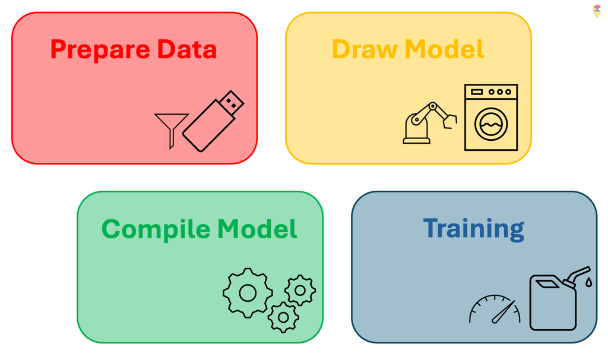

Neural network models are not only easy to understand but also easy to implement using Keras. The entire process is highly structured and doesn’t require much thought. I categorize it into four steps, which I call the “Four-Step Method.”

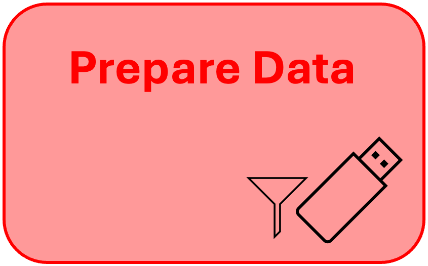

- Data import and preprocessing
- Prepare input pipeline
- Data augmentation

In this course, we can simply understand this step as data import and preprocessing. However, this step is much richer than that, for example pipeline can provide multiple settings for stochastic bach learning, and one may need to consider data augmentation when the sample size is not ideal. You can explore these aspects further in the future.

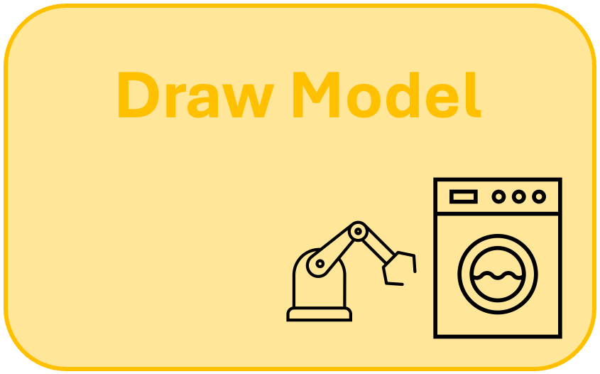

- Overall framework
- layers, neurons, activation function

This step is quite interesting—it’s like drawing, where we visualize our neural network model. I’m fairly good at painting, so I know that the process usually starts with the overall structure before adding details. The same applies here: we first define the overall model architecture and then specify details for each layer, such as the number of neurons, the choice of activation functions, and more.

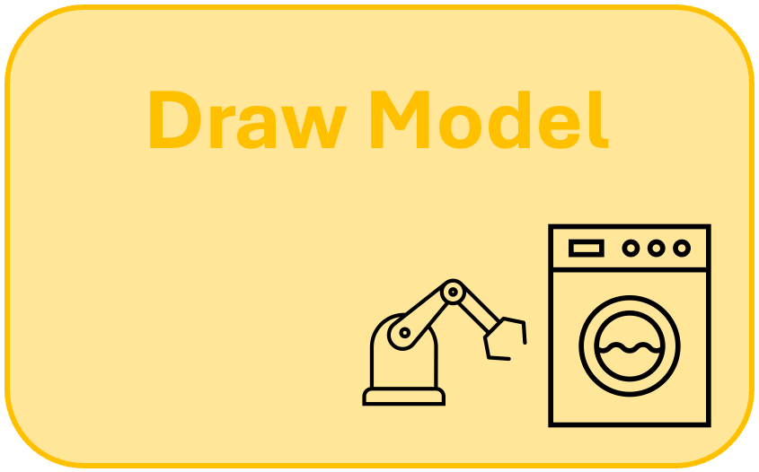

- Overall framework
- layers, neurons, activation function

In the future, you may encounter even more complex model architectures, but the whole process is just like playing with LEGO toys; we just need to connect all the modules together.

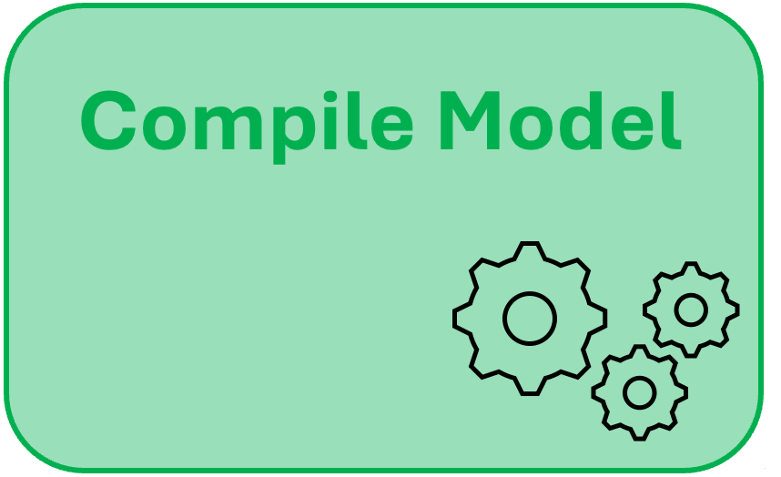

- loss function
- optimizer
- metrics

This step is quite specific—it involves defining the loss function and selecting the optimization algorithm we want to use, such as the Gradient Descent algorithm. Sometimes, we also need to tell Keras which metrics we want to use to evaluate the model’s performance.

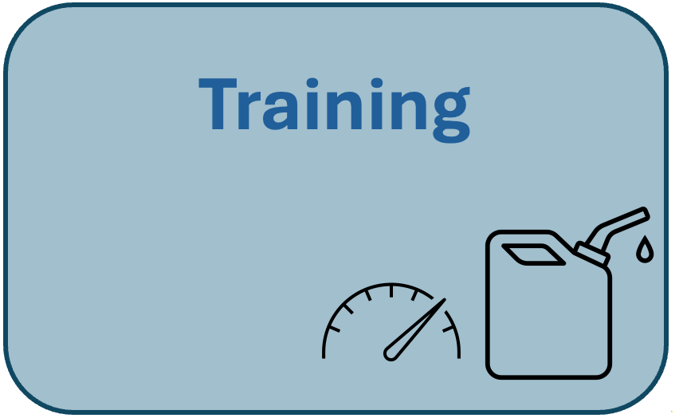

- Input feature variables $X$
- Input target varaibles $y$
- repochs, batch_size, validation_split

The final step is to train our model. As long as you provide the training data $X$ and $y$, along with some parameters, Keras will take care of the rest!